# FeatureBasedMethylation

2022-10-13

```r
library(ggpubr)
library(limma)
```

## Including Plots

source helper functions and load libraries

```r
source("helperFuncs.R")
```

load the featurized data which includes all unified ATACseq peaks with 10 or more methylation reads. Values are average methylation levels in region.

```r
methRegion=readRDS("Data/methFeatures.RDS")
```

load the annotations

```r
methRegion.table=readRDS("Data/methFeatureTable.RDS")
```

load the phenotype information

```r
phenoRegion=readRDS("Data/pheno.RDS")
```

load the ATAC data, we will use this to compare the signal only

```r
atac=readRDS("Data/atac.RDS")
```

# Compare ATAC and methylation signal

compute correlation

```r
iim=match(rownames(methRegion), rownames(atac))
iinotna=which(!is.na(iim))
```

```r
allCors=double(ncol(methRegion))
for(i in 1:ncol(methRegion)){
allCors[i]=cor(methRegion[iinotna,i], atac[iim[iinotna],i], use="p", method="s")
}
```

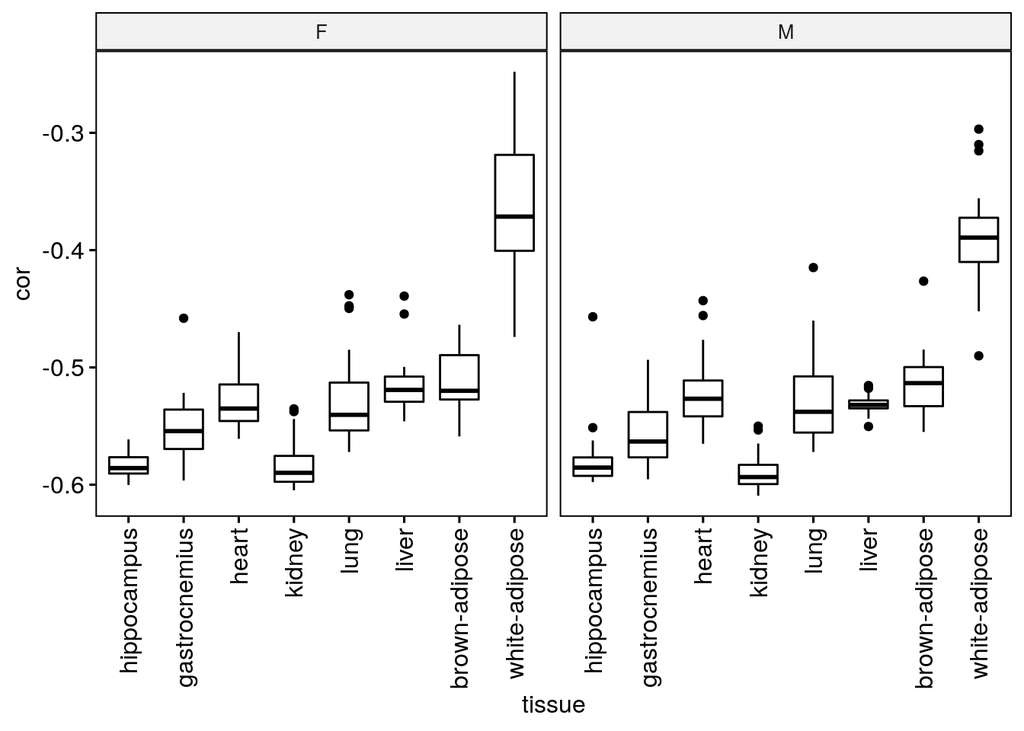

```r
df=phenoRegion
df$cor=allCors
ggboxplot(df, x="tissue", y="cor", facet.by = "Sex")+theme(axis.text.x = element_text(angle = 90, vjust = 0.5, hjust=1))
```

# Normalize data and remove outliers

perform quantile normalization

```r
methRegionQN=normalizeQuantiles(methRegion)
```

Visualize the PCA. We will precompute the SVD

```r
set.seed(1); methRegionQN.svd=rsvd(tscale(methRegionQN), k=10)
```

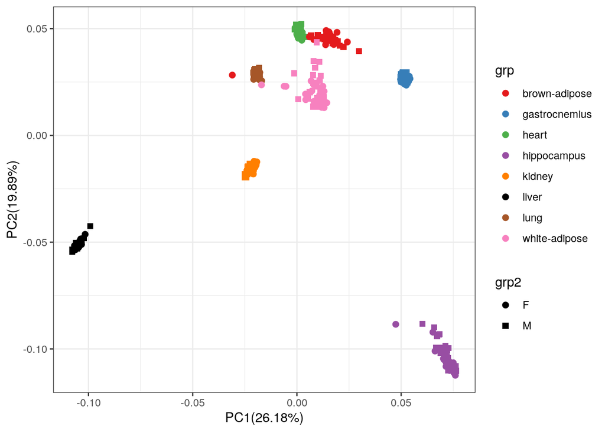

```r
plotPCAggplot(svdres = methRegionQN.svd, grp=phenoRegion$tissue, grp2=phenoRegion$Sex, do.contour = F)
```

get rid of tissue and sex to perform outlier tests

```r
methRegionR=removeVars(methRegionQN,  model.matrix(~1+phenoRegion$tissue*phenoRegion$Sex))
```

New SVD on the residual data

```r
set.seed(1);methRegionR.svd=rsvd(tscale(methRegionR),10)
```

Perform outlier tests and plot them onto the PCA This is a very conservative cutoff of Bonferroni corrected p-value of 0.01.

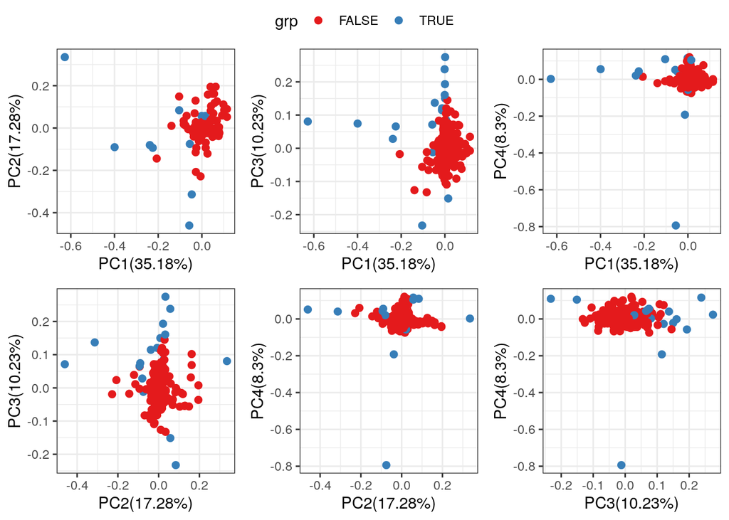

```r
     poutRegion=outlierTest(svdin = methRegionR.svd)
      plotPCAggplotAll(svdres=methRegionR.svd, grp=as.factor(iioutliersRegion<-(poutRegion<0.01/400)), do.contour = F)
```

```r
      iioutliersRegion=which(iioutliersRegion)
```

Remove outliers for all subsequent analysis

```r
      methRegionQN=methRegionQN[, -iioutliersRegion]
      methRegion=methRegion[, -iioutliersRegion]
      methRegionR=methRegionR[, -iioutliersRegion]
      phenoRegion=phenoRegion[-iioutliersRegion,]
```

# Perform differential analysis using limma voom.

The “group4” variable is tissue x training x sex

```r
head(phenoRegion$group4)
```

```
## [1] "hippocampus.w8.Control.M"  "hippocampus.w8.Training.M"
## [3] "hippocampus.w8.Training.M" "hippocampus.w8.Training.M"
## [5] "hippocampus.w8.Training.M" "hippocampus.w8.Training.M"
```

Make the voom object. We are using vooma which is a generic functions that is not RNAseq specific.

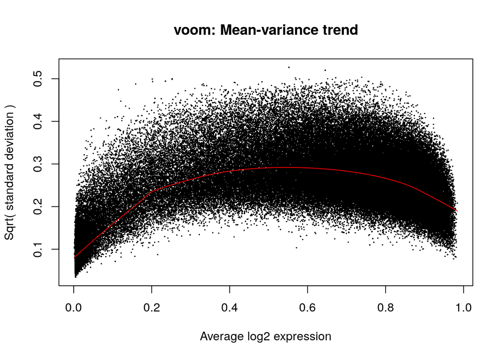

```r
vRegion=vooma(methRegion, model.matrix(~0+phenoRegion$group4), plot=T)
```

load tissue-level contrasts

```r
tcont=readRDS("Data/tcont.RDS")
head(tcont)
```

```
## [1] "hippocampus.w8.Training.F - hippocampus.w8.Control.F"
## [2] "gastrocnemius.w8.Training.F - gastrocnemius.w8.Control.F"
## [3] "heart.w8.Training.F - heart.w8.Control.F"
## [4] "kidney.w8.Training.F - kidney.w8.Control.F"
## [5] "lung.w8.Training.F - lung.w8.Control.F"
## [6] "liver.w8.Training.F - liver.w8.Control.F"
```

Filter un-informative regions based on SVD variance explained. This will be used later for the LV analysis and it may improve differential analysis.

```r
k=5
      lvdatRegion=tscale(methRegionR) #this scales to 0 mean, variance one so error is exactly R2

      set.seed(1);lvdatRegion.svd=rsvd(lvdatRegion, k=k)

      err=rowMeans((lvdatRegion-SVDreconstruct(lvdatRegion.svd,k))^2) #this can be treated as R2



      n=ncol(lvdatRegion) #computing adjustment for adjusterd R2
      adj=n/(n-k)
      varE=1-err*adj
selected.featuresRegion=which(varE>0.1)
length(selected.featuresRegion)
```

```
## [1] 4578
```

Perform limma differential analysis using a wrapper function. This takes a long time on the entire matrix

```r
limresRegion=fitLimma(vRegion, phenoRegion$group4, tcont)
```

Perform limma differential analysis using a wrapper function. This takes a long time on the entire matrix

```r
limresRegionVar=fitLimma(vRegion[selected.featuresRegion,], phenoRegion$group4, tcont)
```

Make the upset plot of top hits at FDR=0.1

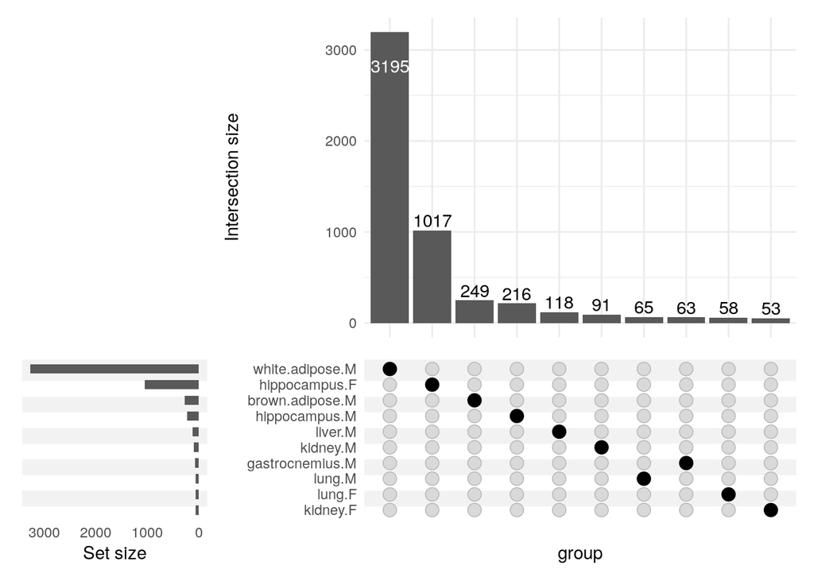

```r
plotUpsetPlotLimma(limresRegion, 0.1)
```

Make the upset plot of top hits at FDR=0.1 for the variance filtered result

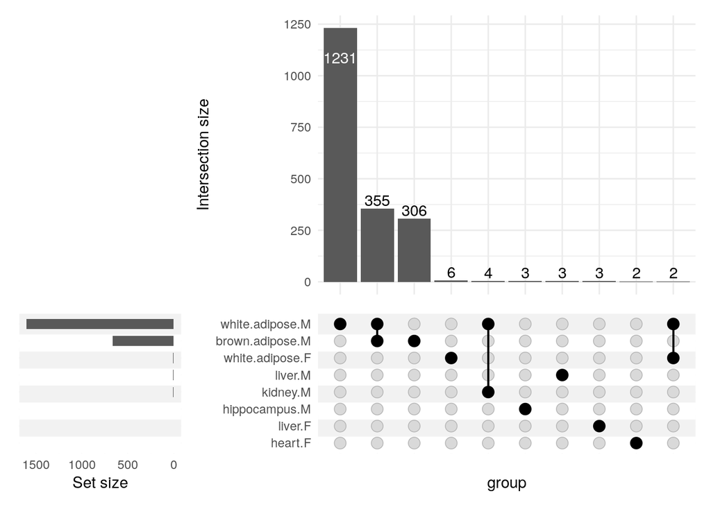

```r
plotUpsetPlotLimma(limresRegionVar, 0.1)
```

The adipose intersection is interesting, we can look at those regions

```r
colnames(limresRegionVar)[regionOfInterestI<-c(15,16)]
```

```
## [1] "brown.adipose.w8.Training.M - brown.adipose.w8.Control.M"
## [2] "white.adipose.w8.Training.M - white.adipose.w8.Control.M"
```

Pick the common regions with a relaxed FDR of 0.1

```r
nnRegions=selectIntersection(limresRegionVar, c(15,16),qvalueCutoff = 0.1, sign = 0)
length(nnRegions)
```

```
## [1] 355
```

Visualize their T-statistics.

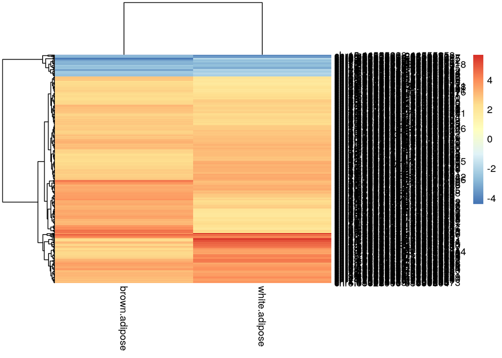

```r
plotdata=limresRegionVar$t[nnRegions,regionOfInterestI]
colnames(plotdata)=sub("\\.w\\d.*", "", colnames(plotdata))
pheatmap(plotdata)
```

```r
nnRegions=selectIntersection(limresRegionVar, c(15,16),qvalueCutoff = 0.1, sign = 1)
length(nnRegions)
```

```
## [1] 321
```

do enrichment in gene space

Get KEGG data from the Enrichr interface

```r
     url = "https://maayanlab.cloud/Enrichr/geneSetLibrary?mode=text&libraryName=KEGG_2021_Human"
download.file(url, "tmp.gmt")
gmtKEGG <- backr::read_gmt("tmp.gmt")
```

```r
foreground=unique(toupper(methRegion.table[nnRegions, "symbol"]))
background=unique(toupper(methRegion.table[rownames(limresRegionVar), "symbol"]))
enrichRes=hypGeomPathForgroundBackgroundEnrichr(foreground, background, gmtKEGG)
```

```
## 192 pathways met min.test and max.test filters
```

```r
kable(enrichRes[enrichRes$fdr<0.1, 1:4])
```

|  | fold | pval | fdr | genes |
| --- | --- | --- | --- | --- |
| Focal adhesion | 5.926625 | 0.0000004 | 0.0000651 | PAK4, ITGA2B, PDGFA, PPP1CC, FLNB, BCAR1, COL6A1, FYN, MYL9, SRC, PIK3CD, COL2A1 |
| Pathways in cancer | 3.937971 | 0.0000007 | 0.0000651 | CTBP2, FGF4, GNAQ, ITGA2B, AXIN2, PDGFA, FZD10, GLI2, DAPK1, PLD1, BCR, WNT5B, CDK6, PIK3CD, HIF1A, WNT7B, TGFBR2 |
| Hippo signaling pathway | 6.384372 | 0.0000018 | 0.0001160 | CCN2, AXIN2, FZD10, PPP1CC, GLI2, RASSF4, WNT5B, WNT7B, TGFBR2, YAP1 |
| Axon guidance | 5.235185 | 0.0000124 | 0.0004773 | PAK4, ROBO2, SEMA5B, LRIG2, FYN, MYL9, SRC, WNT5B, PIK3CD, PLXNC1 |
| Regulation of actin cytoskeleton | 5.235185 | 0.0000124 | 0.0004773 | FGF4, PAK4, ITGA2B, TIAM1, PDGFA, PPP1CC, BCAR1, MYL9, SRC, PIK3CD |
| cAMP signaling pathway | 5.235185 | 0.0000348 | 0.0010047 | TIAM1, HCAR1, PPP1CC, PLD1, NPR1, ATP1A1, MYL9, PDE4B, PIK3CD |
| Ras signaling pathway | 4.592268 | 0.0000417 | 0.0010047 | FGF4, PAK4, NGFR, TIAM1, PDGFA, RGL1, RASA3, PLD1, TEK, PIK3CD |
| Proteoglycans in cancer | 5.121377 | 0.0000419 | 0.0010047 | TIAM1, FZD10, PPP1CC, FLNB, SRC, WNT5B, PIK3CD, HIF1A, WNT7B |
| Basal cell carcinoma | 10.067664 | 0.0000748 | 0.0015951 | AXIN2, FZD10, GLI2, WNT5B, WNT7B |
| Tight junction | 5.910693 | 0.0001204 | 0.0021386 | TIAM1, ARHGEF18, NEDD4L, MYL9, SRC, PRKAG2, RAB8B |
| Protein digestion and absorption | 7.138889 | 0.0001225 | 0.0021386 | KCNQ1, KCNN4, ATP1A1, COL6A1, DPP4, COL2A1 |
| Rap1 signaling pathway | 4.027065 | 0.0001337 | 0.0021394 | FGF4, GNAQ, NGFR, ITGA2B, TIAM1, PDGFA, BCAR1, SRC, TEK, PIK3CD |
| Gastric cancer | 5.725984 | 0.0001493 | 0.0022051 | FGF4, AXIN2, FZD10, WNT5B, PIK3CD, WNT7B, TGFBR2 |
| Human papillomavirus infection | 3.849401 | 0.0001972 | 0.0026880 | ITGA2B, AXIN2, FZD10, COL6A1, WNT5B, CDK6, PIK3CD, WNT7B, COL2A1, PKM |
| Breast cancer | 5.389161 | 0.0002240 | 0.0026880 | FGF4, AXIN2, FZD10, WNT5B, CDK6, PIK3CD, WNT7B |
| Wnt signaling pathway | 5.389161 | 0.0002240 | 0.0026880 | CTBP2, AXIN2, FZD10, WNT5B, TLE1, DAAM1, WNT7B |
| Hepatocellular carcinoma | 5.089763 | 0.0003263 | 0.0036852 | AXIN2, FZD10, WNT5B, CDK6, PIK3CD, WNT7B, TGFBR2 |
| Cushing syndrome | 4.580787 | 0.0006422 | 0.0068505 | GNAQ, AXIN2, FZD10, KCNK2, WNT5B, CDK6, WNT7B |
| PI3K-Akt signaling pathway | 3.313408 | 0.0006862 | 0.0069346 | FGF4, NGFR, ITGA2B, PDGFA, COL6A1, SGK2, CDK6, TEK, PIK3CD, COL2A1 |
| Chronic myeloid leukemia | 6.232363 | 0.0009251 | 0.0088808 | CTBP2, BCR, CDK6, PIK3CD, TGFBR2 |
| MicroRNAs in cancer | 4.164352 | 0.0011636 | 0.0106384 | PAK4, PDGFA, MIR15A, BMF, CDK6, PIK3CD, ST14 |
| FoxO signaling pathway | 4.759259 | 0.0012903 | 0.0107710 | SGK2, PRKAG2, PIK3CD, FOXG1, AGAP2, TGFBR2 |
| Oxytocin signaling pathway | 4.759259 | 0.0012903 | 0.0107710 | GNAQ, PPP1CC, NPR1, MYL9, SRC, PRKAG2 |
| Bacterial invasion of epithelial cells | 7.478836 | 0.0014998 | 0.0116641 | SEPTIN9, BCAR1, SRC, PIK3CD |
| Platelet activation | 4.619281 | 0.0015188 | 0.0116641 | GNAQ, ITGA2B, PPP1CC, FYN, SRC, PIK3CD |
| Insulin resistance | 5.235185 | 0.0021377 | 0.0157859 | PPP1CC, PPP1R3B, NR1H3, PRKAG2, PIK3CD |
| Synaptic vesicle cycle | 6.543982 | 0.0025702 | 0.0182769 | AP2A2, STX2, RAB3A, SYT1 |
| Gastric acid secretion | 6.159041 | 0.0032632 | 0.0216045 | KCNQ1, GNAQ, KCNK2, ATP1A1 |
| Pancreatic cancer | 6.159041 | 0.0032632 | 0.0216045 | PLD1, CDK6, PIK3CD, TGFBR2 |
| Insulin signaling pathway | 4.674272 | 0.0036091 | 0.0230981 | PPP1CC, PPP1R3B, PRKAG2, PIK3CD, MKNK2 |
| Choline metabolism in cancer | 5.816872 | 0.0040735 | 0.0244411 | PDGFA, PLD1, PIK3CD, HIF1A |
| Glycerophospholipid metabolism | 5.816872 | 0.0040735 | 0.0244411 | AGPAT4, LPCAT2, PLD1, ETNK1 |
| Parathyroid hormone synthesis, secretion and action | 4.362654 | 0.0049246 | 0.0282914 | GNAQ, GATA3, PLD1, MAFB, PDE4B |
| Insulin secretion | 5.510721 | 0.0050099 | 0.0282914 | GNAQ, KCNN4, RAB3A, ATP1A1 |
| Alzheimer disease | 3.652455 | 0.0052069 | 0.0285635 | GNAQ, AXIN2, FZD10, WNT5B, PIK3CD, WNT7B |
| Endocytosis | 3.159164 | 0.0058789 | 0.0307237 | AP2A2, SMURF2, NEDD4L, PLD1, SRC, AGAP2, TGFBR2 |
| Melanogenesis | 5.235185 | 0.0060807 | 0.0307237 | GNAQ, FZD10, WNT5B, WNT7B |
| Melanoma | 5.235185 | 0.0060807 | 0.0307237 | FGF4, PDGFA, CDK6, PIK3CD |
| HIF-1 signaling pathway | 4.985891 | 0.0072938 | 0.0359081 | TEK, PIK3CD, HIF1A, MKNK2 |
| Shigellosis | 3.341608 | 0.0081039 | 0.0388987 | SEPTIN9, BCAR1, MYL9, SRC, CBX3, PIK3CD |
| Purine metabolism | 4.759259 | 0.0086566 | 0.0405385 | NPR1, PDE4B, XDH, PKM |
| Endocrine and other factor-regulated calcium reabsorption | 6.543982 | 0.0092730 | 0.0423910 | AP2A2, GNAQ, ATP1A1 |
| Sphingolipid signaling pathway | 4.362654 | 0.0118588 | 0.0529507 | GNAQ, PLD1, FYN, PIK3CD |
| cGMP-PKG signaling pathway | 3.355888 | 0.0151537 | 0.0661254 | GNAQ, PPP1CC, NPR1, ATP1A1, MYL9 |
| Inflammatory mediator regulation of TRP channels | 4.027065 | 0.0157364 | 0.0671421 | GNAQ, PPP1CC, SRC, PIK3CD |
| Chemokine signaling pathway | 3.271991 | 0.0168046 | 0.0701410 | GNAQ, TIAM1, BCAR1, SRC, PIK3CD |
| MAPK signaling pathway | 2.580725 | 0.0173186 | 0.0707483 | FGF4, NGFR, PDGFA, FLNB, TEK, MKNK2, TGFBR2 |
| Phospholipase D signaling pathway | 3.192186 | 0.0185711 | 0.0742845 | AGPAT4, PDGFA, PLD1, FYN, PIK3CD |
| Fluid shear stress and atherosclerosis | 3.739418 | 0.0203305 | 0.0765194 | ITGA2B, PDGFA, SRC, PIK3CD |
| mTOR signaling pathway | 3.739418 | 0.0203305 | 0.0765194 | FZD10, WNT5B, PIK3CD, WNT7B |
| Signaling pathways regulating pluripotency of stem cells | 3.116182 | 0.0204563 | 0.0765194 | AXIN2, FZD10, WNT5B, PIK3CD, WNT7B |
| Non-alcoholic fatty liver disease | 4.907986 | 0.0211225 | 0.0765194 | NR1H3, PRKAG2, PIK3CD |
| Notch signaling pathway | 4.907986 | 0.0211225 | 0.0765194 | CTBP2, NCOR2, TLE1 |
| Pathways of neurodegeneration | 2.707854 | 0.0217745 | 0.0771586 | GNAQ, AXIN2, FZD10, ATXN2, WNT5B, WNT7B |
| Human cytomegalovirus infection | 3.043712 | 0.0224628 | 0.0771586 | GNAQ, BCAR1, SRC, CDK6, PIK3CD |
| Cholinergic synapse | 3.610473 | 0.0229065 | 0.0771586 | KCNQ1, GNAQ, FYN, PIK3CD |
| Viral carcinogenesis | 3.610473 | 0.0229065 | 0.0771586 | SRC, CDK6, PIK3CD, PKM |
| Adherens junction | 4.619281 | 0.0249495 | 0.0795032 | FYN, SRC, TGFBR2 |
| ErbB signaling pathway | 4.619281 | 0.0249495 | 0.0795032 | PAK4, SRC, PIK3CD |
| Renal cell carcinoma | 4.619281 | 0.0249495 | 0.0795032 | PAK4, PIK3CD, HIF1A |
| Epstein-Barr virus infection | 3.490124 | 0.0256729 | 0.0795032 | NCOR2, CDK6, RUNX3, PIK3CD |
| Vascular smooth muscle contraction | 3.490124 | 0.0256729 | 0.0795032 | GNAQ, PPP1CC, NPR1, MYL9 |
| Spinocerebellar ataxia | 3.377539 | 0.0286324 | 0.0837784 | GNAQ, OPA1, ATXN2, PIK3CD |
| Autophagy | 4.362654 | 0.0291248 | 0.0837784 | DAPK1, PIK3CD, HIF1A |
| Pancreatic secretion | 4.362654 | 0.0291248 | 0.0837784 | KCNQ1, GNAQ, ATP1A1 |
| Salivary secretion | 4.362654 | 0.0291248 | 0.0837784 | GNAQ, KCNN4, ATP1A1 |
| Salmonella infection | 2.845209 | 0.0292352 | 0.0837784 | FLNB, EXOC5, MYL9, PIK3CD, RHOJ |
| Cellular senescence | 3.271991 | 0.0317872 | 0.0884513 | PPP1CC, CDK6, PIK3CD, TGFBR2 |
| Thyroid hormone signaling pathway | 3.271991 | 0.0317872 | 0.0884513 | ATP1A1, SRC, PIK3CD, HIF1A |
| Central carbon metabolism in cancer | 4.133041 | 0.0336463 | 0.0922869 | PIK3CD, HIF1A, PKM |

#LV analysis

set a dimensionality, we already get a lot of drop out at k=5 so we don’t need to go past that

```r
k=5
```

perform LV analysis

```r
decompRegion=PLIER::simpleDecomp(lvdatRegion[selected.featuresRegion,], k=k, adaptive.frac = 0.01)
```

```
## Computing SVD
```

```
## [1] "L1 is set to 32.7954236009642"
## [1] "L2 is set to 98.3862708028925"
```

```
## Init
```

```
## converged at  iteration 63
```

Check for global LV dropout by visualizing the loading distribution

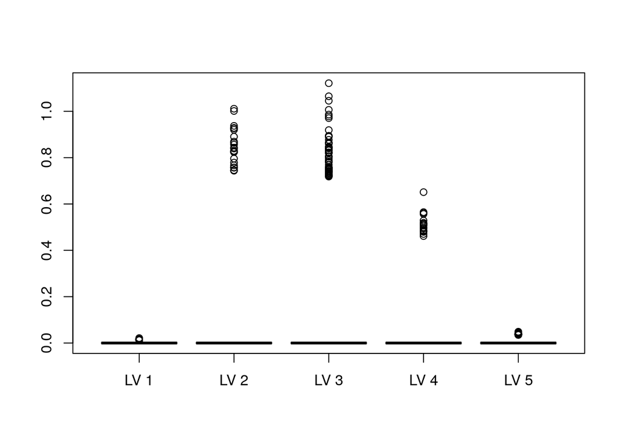

```r
boxplot(decompRegion$Z[1:1000,])
```

Calculate t-tests for tissue contrasts, same as the differential expression analysis with the difference that only LV x tissue combinations that have sufficient variance are included.

```r
reportT=LVtissueReport(decompRegion, 0.2)
kable(reportT)
```

|  | LV | tissue | p.val | fdr |
| --- | --- | --- | --- | --- |
| 1 | LV 2 | hippocampus M | 0.0172730 | 0.0345460 |
| 2 | LV 2 | hippocampus F | 0.0145688 | 0.0291376 |
| 3 | LV 3 | hippocampus F | 0.1123622 | 0.1123622 |
| 4 | LV 3 | heart M | 0.0124063 | 0.0124063 |
| 5 | LV 3 | lung M | 0.0423693 | 0.0847385 |
| 7 | LV 3 | brown-adipose M | 0.0640639 | 0.0640639 |
| 6 | LV 4 | lung M | 0.1416094 | 0.1416094 |
| 8 | LV 4 | brown-adipose M | 0.0363773 | 0.0640639 |

Compute gene enrichments for LVs

Expand the mapping to methylation regions using the “Symbol” key in methRegion.table

```r
#gmtKEGGmethRegion=makeRegionGMT(gmtKEGG,methRegion.table)
gmtKEGGmethRegion=readRDS("Data/gmtKEGGmethRegion.RDS")
```

Evaluate the LVs of interest

```r
sigLVs=unique(reportT[,1])
sigLVsI=match(sigLVs, rownames(decompRegion$B))
tableE=methLVenrichment(decompRegion, gmtKEGGmethRegion, subset =sigLVsI )
```

```
## 206 pathways met min.test and max.test filters
## 206 pathways met min.test and max.test filters
```

```
## Only 0 annotated foreground genes
```

```
## 206 pathways met min.test and max.test filters
```

Check which LVs had enrichment

```r
table(tableE[tableE$fdr<0.1,"LV"])
```

```
##
## LV 2
##    7
```

Only “LV 2” has a coherent signature. It also has the most robust signal in both males and females. We can check the pathways

```r
kable(tableE[tableE$fdr<0.1& tableE$LV=="LV 2", c(1,3,4)])
```

| pathway | fold | pval |
| --- | --- | --- |
| Pathogenic Escherichia coli infection | 17.44665 | 0.0000076 |
| Adipocytokine signaling pathway | 23.84375 | 0.0000190 |
| Insulin resistance | 15.46622 | 0.0001105 |
| Protein processing in endoplasmic reticulum | 22.58882 | 0.0002787 |
| Protein digestion and absorption | 13.84476 | 0.0012212 |
| ECM-receptor interaction | 12.62316 | 0.0016028 |
| Axon guidance | 6.81250 | 0.0025644 |

#promoter methylaton analysis